# BNP Paribas Kaggle Competition

Riki Saito

April 7, 2016

This is a preliminary analysis for the BNP Paribas competition in Kaggle.

Here is the dimensions of the data

```r
#load packages: caret, stringr, Hmisc (use pacman to load packages in one line)
pacman::p_load(caret,stringr,Hmisc)

path = ("C:/Users/Riki/Dropbox/Kaggle/Paribas/")
training = read.csv(paste(path,"train.csv",sep=""),stringsAsFactors=F)

dim(training)
```

```
## [1] 114321    133
```

# Data Cleaning

### 1) Missing Variables

We have a lot of missing values in many of our variables. After a glance at the actual data, we noticed that there is some pattern of missing values across numeric variables: for some observations, values appear to be missing for many of the same numeric variables. Thus we can create new variables based on this information.

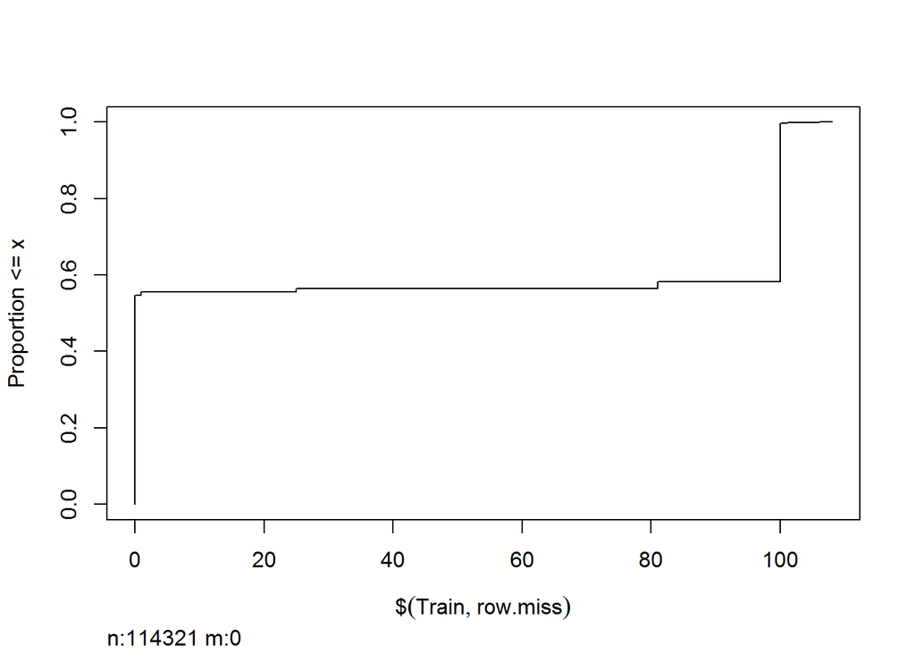

```r
#1) count missing and create variable
Train = training
Train$row.miss = rowSums(is.na(training))   #count of missing values in each row

Ecdf(Train$row.miss)  #diff b/w none and some missing, and b/w <100 and >100
```

```r
cumsum(table(Train$row.miss))
```

```
##      0      1      2      3      4      5      6      7      8      9
##  62561  63495  63518  63522  63523  63557  63583  63585  63589  63593
##     10     11     12     13     15     16     17     25     26     32
##  63595  63600  63601  63603  63605  63610  63611  64484  64485  64486
##     33     35     64     81     82     87    100    101    103    104
##  64487  64489  64525  66570  66574  66576 114014 114224 114250 114253
##    106    107    108
## 114318 114320 114321
```

We can see a big jump at 0 and another jump at 100. We will create 3 variables: 1) count of missing variables, 2) no missing value vs. any missing values, and 3) <100 missing values vs >= 100 missing values.

```r
Train$miss.any = as.numeric(Train$row.miss > 0)   #none vs some missing
sum(Train$miss.any)
```

```
## [1] 51760
```

```r
Train$miss.100plus = as.numeric(Train$row.miss >= 100) #<100 vs >= 100 missing
sum(Train$miss.100plus)
```

```
## [1] 47745
```

```r
dim(Train)
```

```
## [1] 114321    136
```

We see that there are 51760 observations with at least one missing value, and 47745 observations with at least 100 missing values.

### 2) Mean Imputation

For numeric variables, we will replace missing values with the mean to have the least impact on the model when modeling. Question: should we also consider median imputation?

```r
num.vars = which(sapply(training, class) == "numeric")
for(i in num.vars) Train[,i] = ifelse(is.na(Train[,i]), mean(Train[,i], na.rm=TRUE), Train[,i])
```

### 3) Split Multi-character categorical variables

Because some variables are multi-character (strings of length > 1), and have too many levels (i.e. v22 has 18211 levels), we will split each character within each string and consider them as separate variables (i.e. “ABCD” => “A”,“B”,“C”,“D”). The assumption we make here is that, for variables where string length is not fixed, we assume that they are all left-alinged (i.e var = c(“ABCD”, “ABC”) => var1 = c(“A”,“A”); var2= c(“B”,“B”); var3 = c(“C”,“C”); var4 = c(“D”,“”);). Empty values in categorical variables are also considered as a level, and not NA.

```r
splitvar <- function(df){
  for(i in seq_len(ncol(df))){
    if( !class(df[,i]) %in% c("numeric","integer") ){
      x = df[i]
      colname = names(x)
      len = max(nchar(x[,1]))
      str_wide = str_pad(x[,1],side="right",width=len)
      newvar = do.call(rbind, strsplit(str_wide, ""))
    colnames(newvar) = if(len > 1) paste(colname, seq_len(len), sep=".") else colname
    } else newvar = df[i]
    if(i == 1) newdf = newvar else newdf = data.frame(newdf, newvar, stringsAsFactors=F)
  }
  return(newdf)
}

Train.split = splitvar(Train)
dim(Train.split)
```

```
## [1] 114321    142
```

### 4) Convert character variables into numeric

We will convert character variables into dummy variables, with g-1 levels (g = number of levels of unique values of the categorical variable).

```r
Train.mat = model.matrix(~ . - ID - target, data=Train.split)
dim(Train.mat)
```

```
## [1] 114321    465
```

Finally we end up with 465 total variables ready to be used for analysis.

### 5) (Optional) Remove “near-zero” variables

We can also consider removing “near zero” variables, or variables that are mostly non-unique. In the function nearZeroVar in package caret, uniqueCut is the threshold parameter for percent unique (i.e. uniqueCut = 1 => percentage of unique values <= 1%)

```r
nzv = nearZeroVar(Train.mat, uniqueCut = 1, saveMetrics= TRUE)  #determines which columns are "near zero"
vars = subset(row.names(nzv), nzv$nzv==F)
length(vars)
```

```
## [1] 191
```

```r
# keep 191 vars out of 465
```